# Machine learning - Lab 2

# **Iris Dataset**

**@author : Maelwenn LABIDURIE & Albane COIFFE**  
**@email : maelwenn.labidurie@efrei.net & albane.coiffe@efrei.net**  
11/09/2024

## Part 1: Environment Setup

Create a new environment and activate it.

```
conda create -n logistic_regression python=3.8
conda activate logistic_regression
```

Installing the necessary packages: numpy, pandas, scikit-learn, and ydata-profiling.

```
pip install numpy pandas scikit-learn ydata-profiling
```

Create a new kernel usable in Jupyter.

```
pip install ipykernel
python -m ipykernel install --user --name=logistic_regression
```

## Part 2: Data Presentation

Imports needed to load the dataset.

```python
from sklearn.datasets import load_iris
import pandas as pd
```

Load the dataset & Convert it to DataFrame

```python
iris = load_iris()

iris_df = pd.DataFrame(data=iris.data, columns=iris.feature_names)
iris_df['species'] = pd.Categorical.from_codes(iris.target, iris.target_names)
```

Display the first few rows of the dataset

```python
iris_df.head()
```

|  | sepal length (cm) | sepal width (cm) | petal length (cm) | petal width (cm) | species |
| --- | --- | --- | --- | --- | --- |
| 0 | 5.1 | 3.5 | 1.4 | 0.2 | setosa |
| 1 | 4.9 | 3.0 | 1.4 | 0.2 | setosa |
| 2 | 4.7 | 3.2 | 1.3 | 0.2 | setosa |
| 3 | 4.6 | 3.1 | 1.5 | 0.2 | setosa |
| 4 | 5.0 | 3.6 | 1.4 | 0.2 | setosa |

## Part 3: Data Exploration with ydata_profiling

New module needed

```
pip install ipywidgets
```

Imports needed to create the report.

```python
from ydata_profiling import ProfileReport
```

Generate the profiling report

```python
profile = ProfileReport(iris_df, title="Iris Dataset Profiling Report")
profile.to_notebook_iframe()
```

[interactive chart not shown]

Each sample includes four features:

- Sepal length (in cm)
- Sepal width (in cm)
- Petal length (in cm)
- Petal width (in cm)
- Species (Categorical)
1. **Sepal length (cm):**
- **Min** : 4.3
- **Max** : 7.9
- **Meam** : 5.84
- **median** : 5.8
- **Q1** : 5.1
- **Q3** : 6.4

The slight **skewness** (0.31) suggests the data is marginally right-skewed. The histogram reflects a moderate spread across the values, as confirmed by the **standard deviation of 0.83 cm**. The histogram shows that there are very few values close to 4.3 cm and values above 7.5 cm are also relatively rare.

2. **Sepal width (cm):**
- **Min** : 2
- **Max** : 4.4
- **Meam** : 3.06
- **median** : 3
- **Q1** : 2.8
- **Q3** : 3.3

The quartiles show that the majority of the data is concentrated around the median values, with few extreme values. The histogram shows a very prominent peak around 3.0 cm, which is consistent with the median and the mean. There is a significant concentration of values between 2.5 cm and 3.5 cm, indicating that most of the samples have a sepal width close to this range.

3. **Petal length (cm)**:
- **Min**: 1.0
- **Max**: 6.9
- **Q1** (First Quartile): 1.6
- **Median**: 4.35
- **Q3** (Third Quartile): 5.1
- **Range**: 5.9

The distribution of **petal length** shows a wide range, from 1.0 to 6.9 cm. In the histogram, the values appear relatively spread out, with two noticeable peaks at 1.4 cm and 1.5 cm, each representing 13 samples (8.7%).

4. **Petal width (cm)**:
- **Min**: 0.1
- **Max**: 2.5
- **Q1** (First Quartile): 0.3
- **Median**: 1.3
- **Q3** (Third Quartile): 1.8
- **Range**: 2.4

The distribution of **petal width** has a relatively large range, from 0.1 to 2.5 cm. In the histogram, the values appear fairly evenly distributed, although there is a noticeable peak at 0.2 cm, representing 29 samples (19.3%).

5. **Species**:
- **Categorical**, representing the species of Iris flowers:
  - **Iris setosa**
  - **Iris versicolor**
  - **Iris virginica**
- **Iris setosa**: 50 samples
- **Iris versicolor**: 50 samples
- **Iris virginica**: 50 samples

We observe that the **species** are evenly distributed across the dataset, with each class containing 50 samples, making a total of 150 samples.

## Analysis of Key Correlations with Species:

- **Petal width (cm)**: 92%

  **Very High Positive Correlation**: The correlation between petal width and species is strong and positive. This indicates that as the petal width increases, the likelihood of identifying a specific species (such as Iris virginica) increases significantly. Petal width is one of the most reliable features in distinguishing between species.
- **Petal length (cm)**: 89%

  **High Positive Correlation**: Petal length also shows a strong positive correlation with species. Similar to petal width, as the petal length increases, certain species (such as Iris virginica) are more likely to be identified. This makes petal length another important feature for classification.
- **Sepal length (cm)**: 62%

  **Moderate Positive Correlation**: Sepal length has a moderate positive correlation with species. While it is not as strong a predictor as petal dimensions, sepal length still plays a meaningful role in differentiating between species, particularly between Iris setosa and the other two species.
- **Sepal width (cm)**: 45%

  **Low Positive Correlation**: Sepal width shows a weaker correlation with species compared to the other features. Although it still contributes to the classification, it is less influential in distinguishing between the different species of Iris flowers.

```python
import seaborn as sns
sns.pairplot(iris_df, hue="species");
```

[output not shown]

We can observe a strong correlation, particularly between petal width and petal length.

## Part 4: Classification Task

### Create the training and test sets.

```python
from sklearn.model_selection import train_test_split
X = iris_df.drop(columns=['species'])
y = iris_df['species']
X_train, X_test, y_train, y_test = train_test_split(X, y, test_size=0.3, random_state=42)
```

### Preprocess the dataset

```python
from sklearn import preprocessing
scaler = preprocessing.StandardScaler().fit(X_train)
X_scaled = scaler.transform(X_train)
```

### Train a logistic regression classifier

```python
from sklearn.linear_model import LogisticRegression
# Initialize the Logistic Regression model
model = LogisticRegression(max_iter=200);
# Train the model on the training data
model.fit(X_train, y_train);
```

```python
y_pred = model.predict(X_test)
```

### Evaluate the Model

```python
from sklearn.metrics import accuracy_score
from sklearn.metrics import classification_report

accuracy = accuracy_score(y_test, y_pred)
report = classification_report(y_test, y_pred, target_names=['setosa', 'versicolor', 'virginica'])

print(f"Accuracy: {accuracy:.2f}")
print("Classification Report:\n")
print(report)
```

```
Accuracy: 1.00
Classification Report:

              precision    recall  f1-score   support

      setosa       1.00      1.00      1.00        19
  versicolor       1.00      1.00      1.00        13
   virginica       1.00      1.00      1.00        13

    accuracy                           1.00        45
   macro avg       1.00      1.00      1.00        45
weighted avg       1.00      1.00      1.00        45
```

With an accuracy of 100%, the model makes no mistakes.  
The precision and recall are both 100%, meaning there are no false positives or false negatives. As a result, the F1-score is also 100%, reflecting a perfect balance between precision and recall.

### Deprocess the model coefficients and comment the outcomes

[figure not shown]

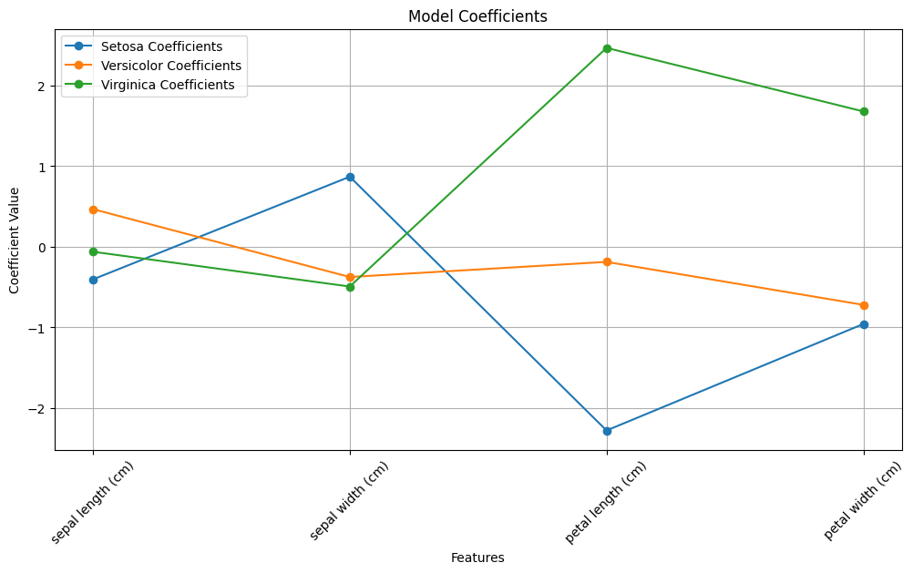

```python
%matplotlib inline
import matplotlib.pyplot as plt
coefs = model.coef_
intercept = model.intercept_
feature_names = X_train.columns

coef_df = pd.DataFrame(coefs, columns=feature_names)
coef_df.index = ['Setosa', 'Versicolor', 'Virginica']

plt.figure(figsize=(12, 6))
for i, coef in enumerate(coefs):
    plt.plot(feature_names, coef, marker='o', label=f'{coef_df.index[i]} Coefficients')
plt.xticks(rotation=45)
plt.xlabel('Features')
plt.ylabel('Coefficient Value')
plt.title('Model Coefficients')
plt.legend()
plt.grid(True)
plt.show()
```

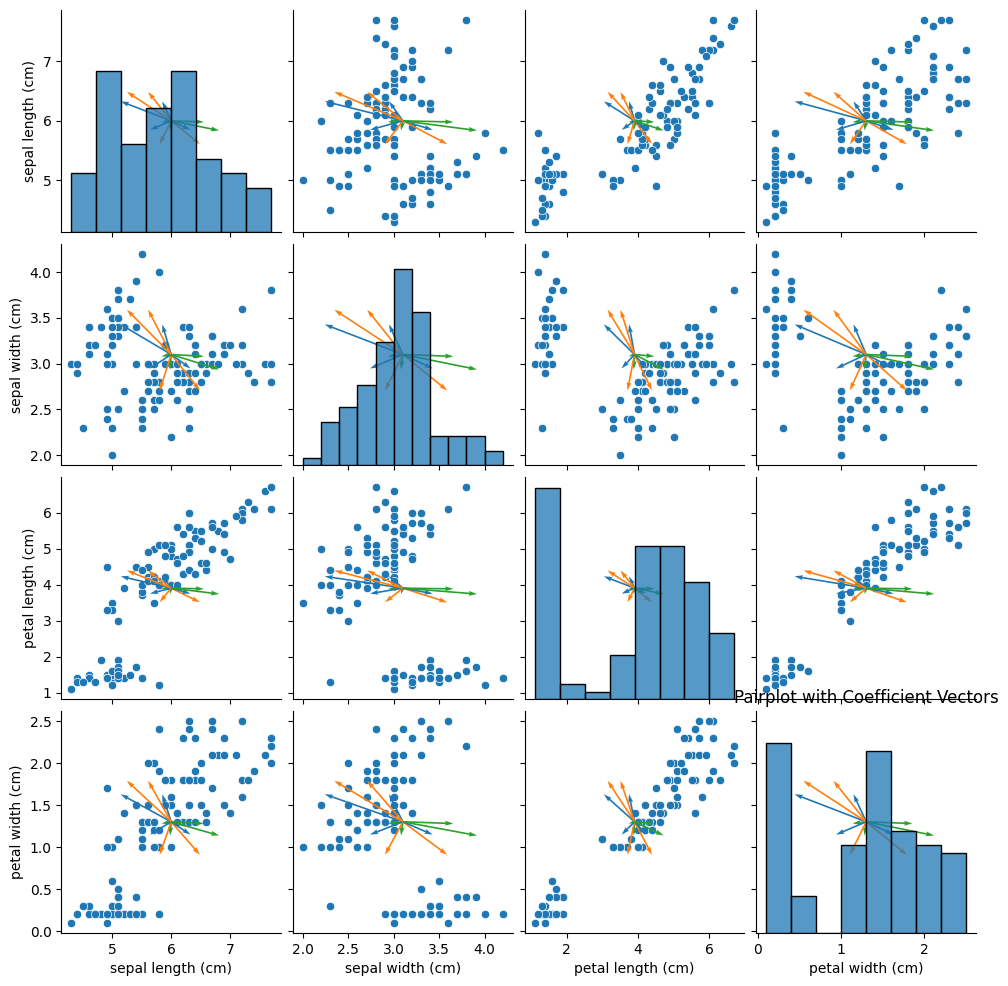

```python
import numpy as np

def draw_coef_vectors(ax, coef, feature_names):
    norms = np.linalg.norm(coef, axis=1)
    coef_normalized = coef / norms[:, np.newaxis]

    for i, feature in enumerate(feature_names):
        xlim = ax.get_xlim()
        ylim = ax.get_ylim()

        x, y = np.linspace(xlim[0], xlim[1], 2), np.linspace(ylim[0], ylim[1], 2)
        X, Y = np.meshgrid(x, y)

        for j in range(coef.shape[0]):
            ax.quiver(X.mean(), Y.mean(), coef_normalized[j, i], coef_normalized[j, (i+1) % 2],
                      angles='xy', scale_units='xy', scale=1, color=f'C{j}', label=f'Class {j+1}')

g = sns.pairplot(X_train)

for ax in g.axes.flatten():
    draw_coef_vectors(ax, coefs, feature_names)

plt.title('Pairplot with Coefficient Vectors')
plt.show()
```

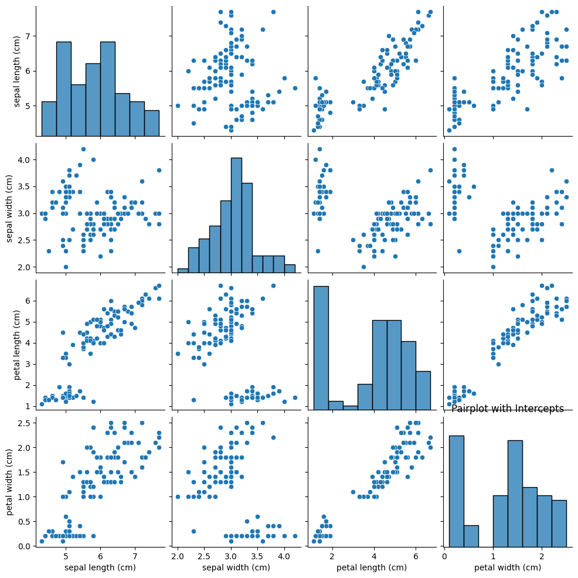

```python
intercepts = model.intercept_

g = sns.pairplot(X_train)
plt.title('Pairplot of Features')

def plot_intercepts(ax, intercepts, feature_names):
    xlim = ax.get_xlim()
    ylim = ax.get_ylim()

    if len(feature_names) == 2:
        for i, intercept in enumerate(intercepts):
            ax.axhline(y=intercept, color=f'C{i}', linestyle='--', label=f'{coef_df.index[i]} Intercept (Horizontal)')
            ax.axvline(x=intercept, color=f'C{i}', linestyle='--', label=f'{coef_df.index[i]} Intercept (Vertical)')
    else:
        pass

for ax in g.axes.flatten():
    plot_intercepts(ax, intercepts, feature_names)

plt.title('Pairplot with Intercepts')
plt.show()
```